# Implicacion del sedentarísmo en la enfermedades crónicas

Samuel Gonzalez, Rodrigo Pascual y Walid Sabhi

2022-10-24

# SEMINARIO FUENTES DE DATOS BIOMÉDICOS Y WEB SEMÁNTICA

# Relacion del sedentarismo con enfermedades

## Introduccion

Vamos ha relacionar el grado de implicación del sedentarismo en una serie de enfermedades crónicas, para ello hemos escojido dos informes del centro Nacional de Estadístaca español, la primera tabla “enfermedades_cronicas” contendrá una una lista con la tasa de enfermededes crónicas según el sexo y la comunidad autónoma, como hay muchas enfermedades seleccionaremos unas pocas que sean de interés para nuestro estudio y trataremos de encontar si hay relación o no con nuestra segunda tabla “sedentarismo” que nos aportará el índice de este según de nuevo el sexo y la comunidad autónoma.

## Objetivos(max. 3):para cada objetivo un metodo y un resultado

1. Escoger 6 Enfermedades que puedan tener relacion con el sedentarismo y ver el índice de estas en cada Comunudad Autónoma, Hemos escogido la hemorroides, el ictus, las migrañas, la osteoporosis, la tensión alta y la varices en las piernas
2. Ver el índice de sedentarísmo de cada comunidad autónoma en tablas por separado para ver cual de ellas lo tiene mas bajo o mas alto y poder ver las primeras relaciones entre sedentarísmo y enfermedad crónica
3. Ver si realmente estas enfermedades están o no relacionadas con el sedentarísmo

## Métodos:

### Paquetes usadas:

```r
library(readr)
library(ggplot2)
library(dplyr)
library(tidyverse)
library(ggplot2)
library(forcats)
library(hrbrthemes)
library(viridis)
library(rjson)
library(XML)
```

# Resultados y Analisis de los resultados

presentando las dos tablas con las cual vamos a sacar los resultados Datos importados por CSV

```r
enfermedades <- read_delim(file = "input/enfermedades_cronicas1.csv",delim = ";",show_col_types = FALSE)
sedentarismo <- read_delim(file = "input/sedentarismo.csv",delim = ";",show_col_types = FALSE)
```

Datos importados por JSON

```r
enfermedades_json <- fromJSON(file = "input/enfermedades_cronicas1.json")
sedentarismo_json <- fromJSON(file = "input/sedentarismo.json")
```

Datos importados por XML

```r
enfermedades_xml <- xmlParse(file="input/enfermedades_cronicas1.xml")
sedentarismo_xml <- xmlParse(file="input/sedentarismo.xml")
```

## Primera grafica (objetivo 1)

gráficas por comunidad, sexo y enfermedad padecida Indica en cada comunidad autónoma que enfermedad es mas padecida según cada sexo

```r
#Paso de enfermedades y sedentarismo a data frame para hacer el join
enfermedades <- data.frame(enfermedades)
sedentarismo <- data.frame(sedentarismo)

#Cambiamos la columna de Total de str a numeric
#sedentarismo<- sedentarismo%>%
#  transmute(Sexo, Comunidades.y.Ciudades.Autónomas,Sí.o.no, Total = as.numeric(Total))

#enfermedades<- enfermedades%>%
# transmute(Sexo, Comunidades.y.Ciudades.Autónomas, Enfermedades, Sí.o.no, Total = as.numeric(Total))
```

1.Hacemos un full join con los data frames anteriores a partir de las columnas Sexo, Comunidades.y.Ciudades.Autónomas y Si.o.no

```r
data <- full_join(x = enfermedades,
            y = sedentarismo,
            by = c("Sexo", "Comunidades.y.Ciudades.Autónomas" ,"Sí.o.no"))
```

2.Filtramos la tabla anterior solo por las enfermedades que vamos a estudiar

```r
data_menosEnfermedades <- data %>%
  filter(Enfermedades == "Tensión alta" | Enfermedades == "Varices en las piernas" | Enfermedades == "Migraña o dolor de cabeza frecuente" | Enfermedades == "Ictus (embolia, infarto cerebral, hemorragia cerebral)" | Enfermedades =="Hemorroides" | Enfermedades == "Osteoporosis")
```

3.Tabla de solo las personas que padecen la enfermedad

```r
data_soloSi <- data_menosEnfermedades %>% filter(Sí.o.no == "Sí")
```

gráficas por comunidad, sexo y enfermedad padecida Indica en cada comunidad autónoma que enfermedad es mas padecida según cada sexo

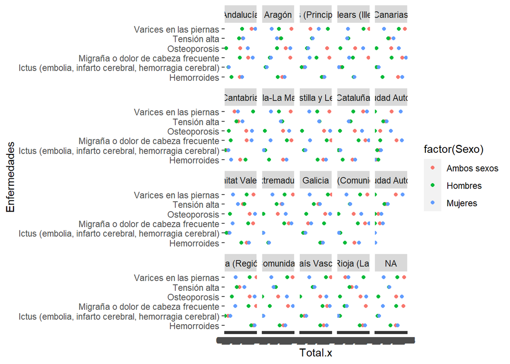

```r
ggplot(data = data_soloSi, aes(x = Total.x, y = Enfermedades)) +
  geom_point(aes(colour = factor(Sexo))) +
  facet_wrap(~ Comunidades.y.Ciudades.Autónomas)
```

### Anlisis del resultado:

Los puntos verdes de la tabla pertenecen a los hombres y los azules pertenecen a las mujeres, esto podemos ver que es realmente asi por ejemplo en el caso de la osteoporosis, enfermedad mucho más presente en mujeres que en hombres. Esto se interpreta de forma que los puntos mas cercanos es que tiene un menor índice de casos por habitante, un buen ejemplo para visualizar esto es fijarnos en los ictus, que se podicen con mucha menos frecuencia que por ejemplo las varices. Respecto a las diferencias en cuanto a las comunudades autónomas no sos muy notorias.

## Segunda gráfica (objetivo 2)

Filtramos la tabla para que no salga al representar la gráfica el total

```r
data_sedentarismo <- data_menosEnfermedades %>% filter(Sí.o.no == "Sí" | Sí.o.no == "No")
```

gráficas por comunidad, sexo y sedentarismo Indica en cada comunidad autónoma que sexo es más sedentario ademas de que comunidad autonoma es mas sedentaria en general

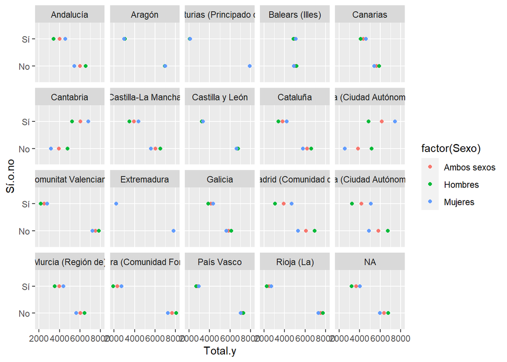

```r
ggplot(data = data_sedentarismo, aes(x = Total.y, y = Sí.o.no)) +
  geom_point(aes(colour = factor(Sexo))) +
  facet_wrap(~ Comunidades.y.Ciudades.Autónomas)
```

## Tercera y cuarta gráfica (objetivo 3)

grafica de dispersión: Sedentarismo en funcion de la enfermedad

1º Vamos a modificar los datos de la columna “Total.x” ya que al estar escritos con coma los decimales estos aparecen en forma de character, si los intentamos cabiar a numerico directamente, nos aparecerá un error de coherción. Para solucionar este error itroduciremos la siguiente linea:

```r
db <- gsub(",",".",data_soloSi$Total.x)
data_soloSi$Total.x = as.numeric(db)
```

Grafica con todas las enfemedades y con una linea de tendencia General (no muy reperesentativa) además de una recta por cada enfermedad

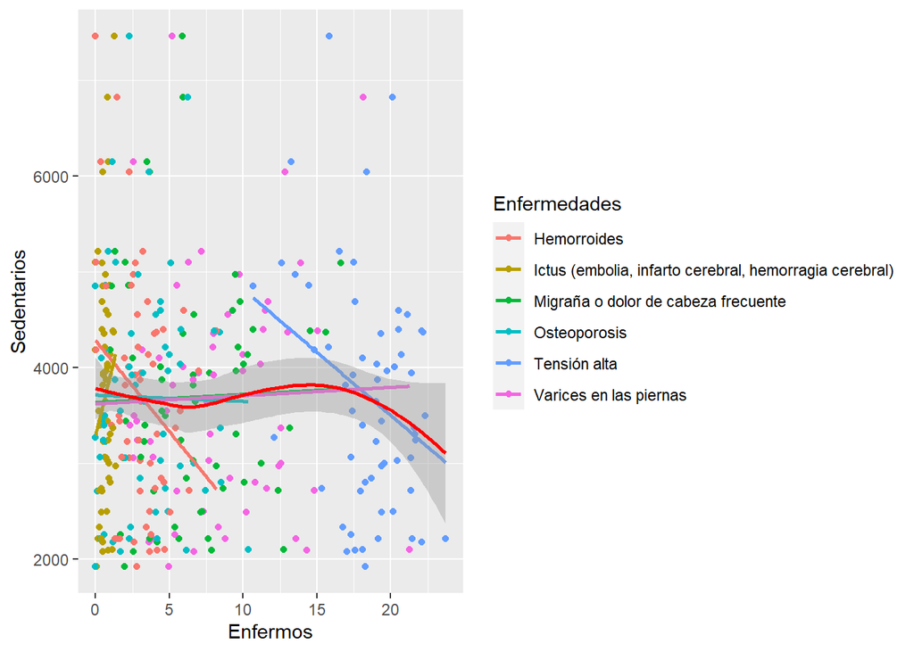

```r
ggplot(data = data_soloSi, aes(x = Total.x, y = Total.y, colour = Enfermedades)) +
  geom_point(aes(colour = Enfermedades)) +
  geom_smooth(se = FALSE, method = lm)+
  geom_smooth(colour = "red", linewidth = 1.75)+
  labs(x = "Enfermos", y = "Sedentarios")
```

Representación de las seis enfermedades seleccionadas, cada una de ellas con su linea de tendencia, podemos ver alguna relacion entre cierta enfermedad y el sedentarismo…

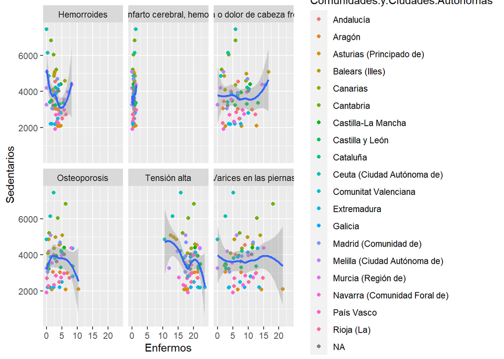

```r
ggplot(data = data_soloSi, aes(x = Total.x, y = Total.y))+
  geom_point(aes(colour = Comunidades.y.Ciudades.Autónomas))+
  geom_smooth(span = 0.8) +
  facet_wrap(~ Enfermedades)+
  labs(x = "Enfermos", y = "Sedentarios")
```

### Anlisis del resultado y Conclusión:

No vemos una clara relacion entre el sedentarismo y las enfermedades seleccionadas, la única enfermedad en la podemos ver una clara tendencia al alza es en los los casos de ictus derebral. Para ejemplificar de nuevo nos fijaremos en la ciudad autónoma de Ceuta, si pensamos q un alto índice dde sedentarismo afecta de manera negativa este punto de Ceuta representado con un color azúl a parte de estar muy arriba por su alto índice de sedentarismo, además debería de estar muy a la derecha significando asi que tambén hay muchos casos de enfermedad, realmente nos fijamos y no es del todo cierto.